# Assignment 4

Before working on this assignment please read these instructions fully. In the submission area, you will notice that you can click the link to **Preview the Grading** for each step of the assignment. This is the criteria that will be used for peer grading. Please familiarize yourself with the criteria before beginning the assignment.

This assignment requires that you to find **at least** two datasets on the web which are related, and that you visualize these datasets to answer a question with the broad topic of **weather phenomena** (see below) for the region of **Dhahran, Eastern Province, Saudi Arabia**, or **Saudi Arabia** more broadly.

You can merge these datasets with data from different regions if you like! For instance, you might want to compare **Dhahran, Eastern Province, Saudi Arabia** to Ann Arbor, USA. In that case at least one source file must be about **Dhahran, Eastern Province, Saudi Arabia**.

You are welcome to choose datasets at your discretion, but keep in mind **they will be shared with your peers**, so choose appropriate datasets. Sensitive, confidential, illicit, and proprietary materials are not good choices for datasets for this assignment. You are welcome to upload datasets of your own as well, and link to them using a third party repository such as github, bitbucket, pastebin, etc. Please be aware of the Coursera terms of service with respect to intellectual property.

Also, you are welcome to preserve data in its original language, but for the purposes of grading you should provide english translations. You are welcome to provide multiple visuals in different languages if you would like!

As this assignment is for the whole course, you must incorporate principles discussed in the first week, such as having as high data-ink ratio (Tufte) and aligning with Cairo’s principles of truth, beauty, function, and insight.

Here are the assignment instructions:

- State the region and the domain category that your data sets are about (e.g., **Dhahran, Eastern Province, Saudi Arabia** and **weather phenomena**).
- You must state a question about the domain category and region that you identified as being interesting.
- You must provide at least two links to available datasets. These could be links to files such as CSV or Excel files, or links to websites which might have data in tabular form, such as Wikipedia pages.
- You must upload an image which addresses the research question you stated. In addition to addressing the question, this visual should follow Cairo's principles of truthfulness, functionality, beauty, and insightfulness.
- You must contribute a short (1-2 paragraph) written justification of how your visualization addresses your stated research question.

What do we mean by **weather phenomena**? For this category you might want to consider seasonal changes, natural disasters, or historical trends.

## Tips

- Wikipedia is an excellent source of data, and I strongly encourage you to explore it for new data sources.
- Many governments run open data initiatives at the city, region, and country levels, and these are wonderful resources for localized data sources.
- Several international agencies, such as the [United Nations](http://data.un.org/), the [World Bank](http://data.worldbank.org/), the [Global Open Data Index](http://index.okfn.org/place/) are other great places to look for data.
- This assignment requires you to convert and clean datafiles. Check out the discussion forums for tips on how to do this from various sources, and share your successes with your fellow students!

## Example

Looking for an example? Here's what our course assistant put together for the **Ann Arbor, MI, USA** area using **sports and athletics** as the topic. Example Solution File

```python
import pandas as pd
import numpy as np
import matplotlib.pyplot as plt
import seaborn as sns
plt.rcParams['figure.figsize'] = (8.5, 5.5)
% matplotlib notebook
plt.style.use('seaborn-colorblind')
```

```python
!tar chvfz notebook.tar.gz *
```

[output not shown]

# Data Processing

```python
suicide_rates = pd.read_csv('suicide_rates.csv')
happ_15 = pd.read_csv('2015.csv')

suicide_rates = suicide_rates[(suicide_rates['year'] == 2015)]
suicide_rates = suicide_rates[['country', 'suicides/100k pop', 'gdp_per_capita ($)']]
suicide_rates.reset_index(drop=True, inplace=True)

df = pd.merge(suicide_rates, happ_15, left_on='country', right_on='Country')
df.drop('Country', axis=1, inplace=True)
df = df.groupby(['country', 'gdp_per_capita ($)','Happiness Score', 'Health (Life Expectancy)'])['suicides/100k pop'].mean().to_frame(name = 'suicides/100k pop mean').reset_index()
df.sort_values(by='Happiness Score', ascending=False, inplace=True);

df['gdp_per_capita ($)'] = df['gdp_per_capita ($)'].map(lambda x: x / 1000.0)
df.rename(columns={"Health (Life Expectancy)": "Life Expectancy"}, inplace=True)
```

### Data

```python
df.head()
```

|  | country | gdp_per_capita ($) | Happiness Score | Life Expectancy | suicides/100k pop mean |
| --- | --- | --- | --- | --- | --- |
| 45 | Switzerland | 86.068 | 7.587 | 0.94143 | 13.721667 |
| 20 | Iceland | 54.909 | 7.561 | 0.94784 | 11.720833 |
| 11 | Denmark | 55.972 | 7.527 | 0.87464 | 10.118333 |
| 34 | Norway | 79.187 | 7.522 | 0.88521 | 11.369167 |
| 14 | Finland | 44.862 | 7.406 | 0.88911 | 13.432500 |

### Statistics

```python
df.describe()
```

|  | gdp_per_capita ($) | Happiness Score | Life Expectancy | suicides/100k pop mean |
| --- | --- | --- | --- | --- |
| count | 53.000000 | 53.000000 | 53.000000 | 53.000000 |
| mean | 28.225660 | 6.218264 | 0.807952 | 11.144072 |
| std | 25.450618 | 0.921575 | 0.127157 | 6.515303 |
| min | 1.285000 | 4.297000 | 0.276880 | 1.083333 |
| 25% | 9.431000 | 5.548000 | 0.731720 | 6.454167 |
| 50% | 16.696000 | 6.329000 | 0.811600 | 10.577500 |
| 75% | 44.862000 | 6.946000 | 0.892840 | 14.617500 |
| max | 107.456000 | 7.587000 | 1.025250 | 32.123333 |

# Analysis and Visualization for Suicide rates

### Correlation Matrix

There is not a strong relationship between any of the featuers with suicide rates based on the correlation matrix, On the other hand, there is quite a strong relationship between all other variables

```python
corr = df.corr()
corr.style.background_gradient()
```

|  | gdp_per_capita ($) | Happiness Score | Life Expectancy | suicides/100k pop mean |
| --- | --- | --- | --- | --- |
| gdp_per_capita ($) | 1 | 0.682644 | 0.64085 | 0.0404934 |
| Happiness Score | 0.682644 | 1 | 0.579764 | -0.0131756 |
| Life Expectancy | 0.64085 | 0.579764 | 1 | 0.155735 |
| suicides/100k pop mean | 0.0404934 | -0.0131756 | 0.155735 | 1 |

## Scatter and KDE

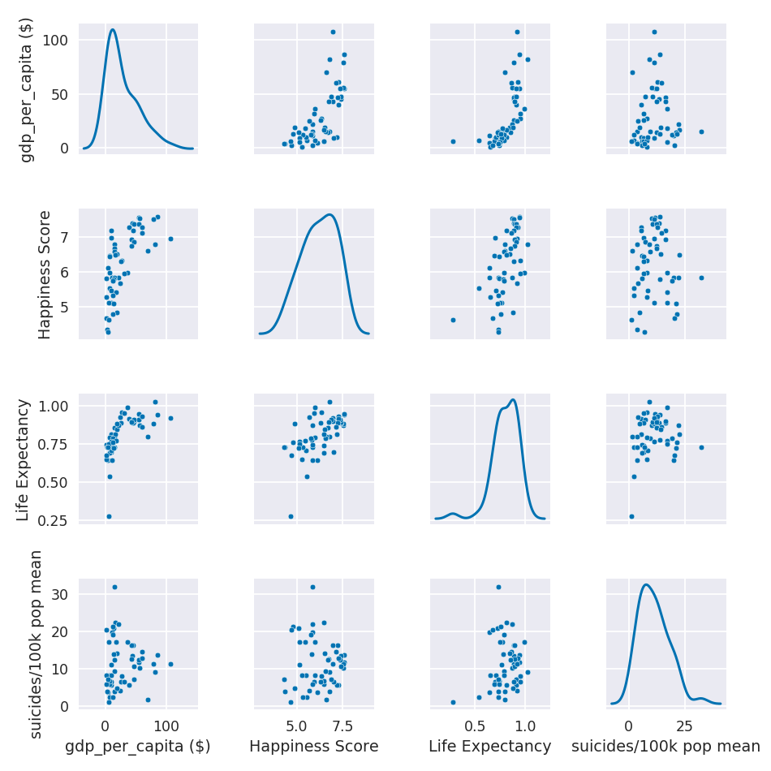

```python
sns.pairplot(df, diag_kind='kde', size=1.9, plot_kws={"s": 15});
```

[figure not shown]

```python
OldRange = (np.max(df['Happiness Score']) - np.min(df['Happiness Score']))
NewRange = (np.max(df['suicides/100k pop mean']) - np.min(df['suicides/100k pop mean']))

OldMin = np.min(df['Happiness Score'])
newMin = np.min(df['suicides/100k pop mean'])

v1 = df['Happiness Score'].map(lambda x: (((x - OldMin) * NewRange) / OldRange) + newMin)
v2 = df['suicides/100k pop mean']

plt.figure()
plt.scatter(v1,v2, alpha=0.7)
plt.xlabel('gdp_per_capita ($) / 1000')
plt.ylabel('suicides/100k pop mean')
plt.title('Happiness Score VS Suicides per 100k of Population')
```

## Normed histograms with KDE

#### There might be a pattern here, they rise and fall together at the beginning, but it is not consistent

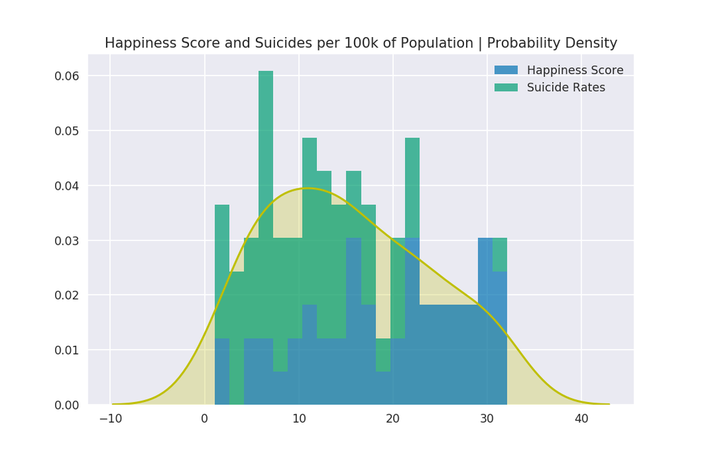

```python
plt.figure()
plt.hist([v1, v2], histtype='barstacked', normed=True, bins=20,  alpha=0.7, label=['Happiness Score', 'Suicide Rates']);
sns.kdeplot(np.concatenate((v1, v2)), shade=True, color="y")
plt.legend()
plt.title('Happiness Score and Suicides per 100k of Population | Probability Density')
```

## Pearson Coff.

Showing very weak relationship

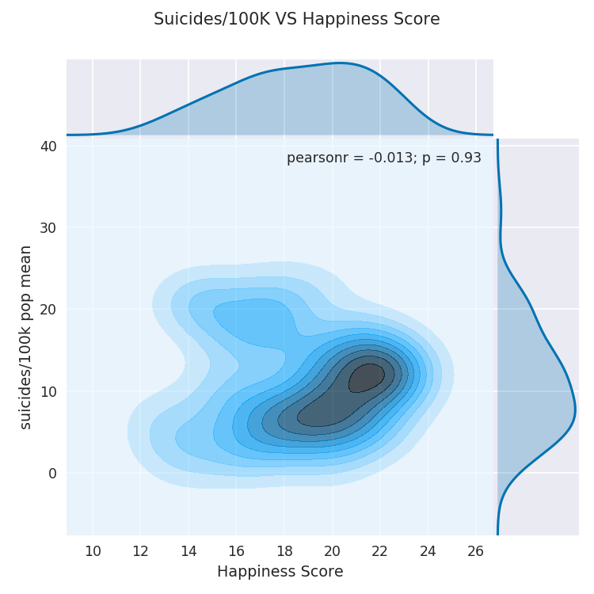

```python
grid = sns.jointplot(v1, v2, alpha=0.7, kind='kde', space=0);
plt.subplots_adjust(top=0.9)
grid.fig.suptitle('Suicides/100K VS Happiness Score')
```

# Analysis and Visualization for other variables

### GDP VS Happiness

There is a strong relationship

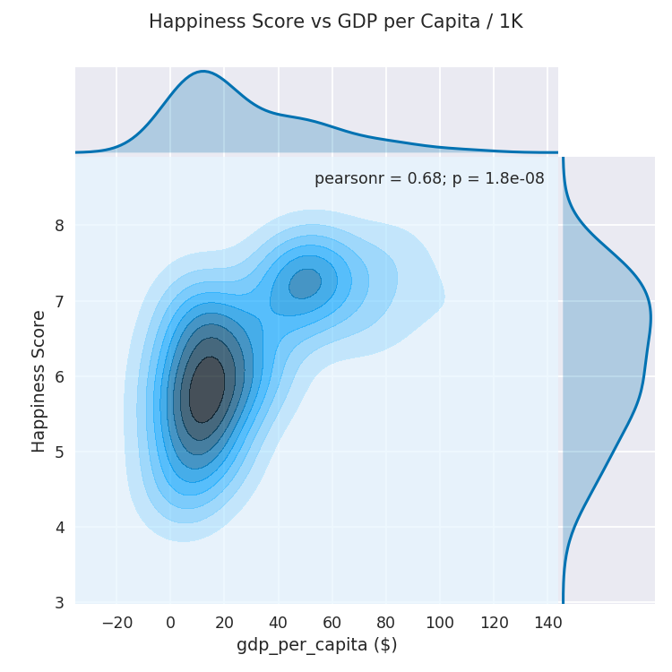

```python
gdp = df['gdp_per_capita ($)']
hScore = df['Happiness Score']


grid = sns.jointplot(gdp, hScore, alpha=0.7, kind='kde', space=0);
plt.subplots_adjust(top=0.9)
grid.fig.suptitle('Happiness Score vs GDP per Capita / 1K')
```

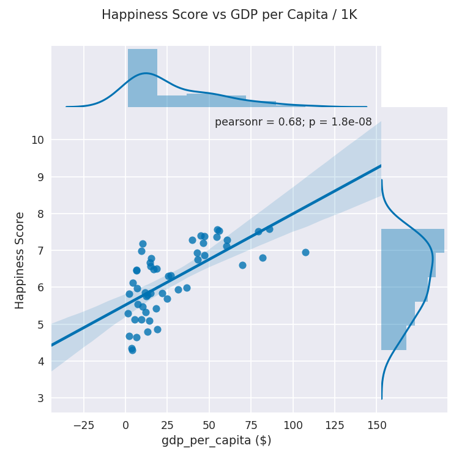

```python
grid = sns.jointplot(gdp, hScore, kind='reg', space=0);
plt.subplots_adjust(top=0.9)
grid.fig.suptitle('Happiness Score vs GDP per Capita / 1K')
```

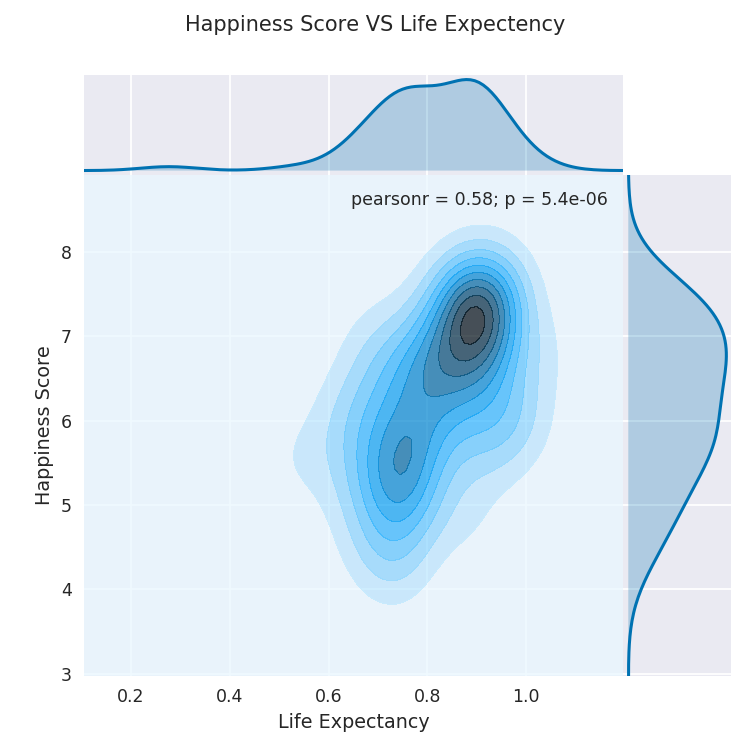

```python
lifeExpect = df['Life Expectancy']

grid = sns.jointplot(lifeExpect, hScore, alpha=0.7, kind='kde', space=0);
plt.subplots_adjust(top=0.9)
grid.fig.suptitle('Happiness Score VS Life Expectency')
```

### All analyses shows that there is no actual relationship between suicide rates and happiness.

### An exaggerated measure of sadness might be correlated with suicide rates, I just feel like most people underestimate how happy they are and get themselves into the drama and attention-seeking whirlpool which does very well with creating sadness from nothing by a consistent self convince.

### Of course, I'm just talking about the majority, and this is just an opinion.